# Winter2021

## Fabrice Gbah

```python
#Ensure we are using the right kernel
print (sc.version)
```

```
2.4.0-cdh6.3.0
```

```python
from pyspark.sql import SparkSession
from pyspark.sql import functions as F
import matplotlib.pyplot as plt
import pandas as pd
%matplotlib inline
```

```python
#spark = SparkSession.builder.appName('uchicago_tweets').getOrCreate()

#change configuration settings on Spark
#conf = spark.sparkContext._conf.setAll([('spark.executor.memory', '4g'), ('spark.app.name', 'Spark Updated Conf'), ('spark.executor.cores', '4'), ('spark.cores.max', '4'), ('spark.driver.memory','4g')])

#print spark configuration settings
#spark.sparkContext.getConf().getAll()
```

```python
#!pip3 install shutil --user
#!pip3 install sh --user
```

```python
import os
import shutil
import sh
import json
from pyspark.sql.functions import *
#from pyspark.sql import functions as F
from pyspark.sql.types import *
```

## Read the tweets

```python
!hadoop fs -du -s -h '/user/ivy2/Tweets/'
```

```
WARNING: log4j.properties is not found. HADOOP_CONF_DIR may be incomplete.
Java HotSpot(TM) 64-Bit Server VM warning: ignoring option MaxPermSize=512M; support was removed in 8.0
2.3 T  6.8 T  /user/ivy2/Tweets
```

```python
directory = 'hdfs:///user/ivy2/Tweets/'
file = '*.json'
path = directory + file
```

```python
%time tweets_df = spark.read.json(path)
```

```
CPU times: user 57.6 ms, sys: 18.2 ms, total: 75.8 ms
Wall time: 8min 20s
```

```python
tweets_df.count()
```

```
350469313
```

## Identify tweets related to UChicago and 3-4 universities of your choice

```python
spark.conf.set("spark.sql.repl.eagerEval.enabled",True)
```

```python
%time user_data=tweets_df.select(['created_at','user.id','text','user.location','user.followers_count','user.name','user.statuses_count','user.listed_count'])
```

```
CPU times: user 6.62 ms, sys: 1.45 ms, total: 8.06 ms
Wall time: 86.7 ms
```

```python
user_data = user_data.withColumn("statuses_count", user_data["statuses_count"].cast(IntegerType()))
```

```python
user_data = user_data.withColumn("followers_count", user_data["followers_count"].cast(IntegerType()))
```

```python
user_data = user_data.withColumn("listed_count", user_data["listed_count"].cast(IntegerType()))
```

```python
user_data.printSchema()
```

```
root
 |-- created_at: string (nullable = true)
 |-- id: long (nullable = true)
 |-- text: string (nullable = true)
 |-- location: string (nullable = true)
 |-- followers_count: integer (nullable = true)
 |-- name: string (nullable = true)
 |-- statuses_count: integer (nullable = true)
 |-- listed_count: integer (nullable = true)
```

```python
tweets_df_uchicago=user_data.filter(tweets_df['text'].contains('UChicago' ))
```

```python
tweets_df_uic=user_data.filter(tweets_df['text'].contains('UIC'))
```

```python
tweets_df_yale=user_data.filter(tweets_df['text'].contains('Yale'))
```

```python
tweets_df_h=user_data.filter(tweets_df['text'].contains('Harvard'))
```

```python
tweets_df_uchicago.count()
```

```
320703
```

```python
tweets_df_h.count()
```

```
4235093
```

## Discard irrelevant tweets

```python
tweets_df_uc_clean=tweets_df_uchicago.filter(col('text').isNotNull()).cache()
```

```python
tweets_df_uic_clean=tweets_df_uic.filter(col('text').isNotNull()).cache()
```

```python
tweets_df_yale_clean=tweets_df_yale.filter(col('text').isNotNull()).cache()
```

```python
tweets_df_harvard_clean=tweets_df_h.filter(col('text').isNotNull()).cache()
```

## Complete thorough EDA to identify which variables you can use to profile the Twitterers

```python
%time tweets_df_uc_clean.describe(['followers_count']).show()
```

```
+-------+------------------+
|summary|   followers_count|
+-------+------------------+
|  count|            320703|
|   mean| 6449.691730354876|
| stddev|176166.26737216304|
|    min|                 0|
|    max|          40779493|
+-------+------------------+

CPU times: user 55.9 ms, sys: 13.5 ms, total: 69.4 ms
Wall time: 7min 20s
```

```python
%time tweets_df_uc_clean.describe(['statuses_count']).show()
```

```
+-------+------------------+
|summary|    statuses_count|
+-------+------------------+
|  count|            320703|
|   mean|26644.210316086846|
| stddev| 78549.59362223216|
|    min|                 1|
|    max|           3506013|
+-------+------------------+

CPU times: user 2.05 ms, sys: 2.21 ms, total: 4.26 ms
Wall time: 7.83 s
```

## 4) Identify the most prolific / influential Twitterers

- By message volume
- By message retweet
- How much are they tweeting about the Universities vs. other topics?

```python
%time df_uchicago_retwt=tweets_df_uc_clean.groupBy('id').agg(sum('listed_count').alias('sum_listed_count'))
```

```
CPU times: user 3.11 ms, sys: 2.71 ms, total: 5.82 ms
Wall time: 36.5 ms
```

```python
%time df_uchicago_retwt.orderBy('sum_listed_count',ascending=False).show(5)
```

```
+---------+----------------+
|       id|sum_listed_count|
+---------+----------------+
|131144285|         3358870|
| 14987728|          617625|
|   759251|          544696|
| 51241574|          476578|
| 15164565|          461142|
+---------+----------------+
only showing top 5 rows

CPU times: user 4.42 ms, sys: 782 µs, total: 5.2 ms
Wall time: 14.5 s
```

```python
%time df_uchicago=tweets_df_uc_clean.groupBy('id').agg(sum('statuses_count').alias('sum_statuses_count'))
```

```
CPU times: user 2.53 ms, sys: 1.21 ms, total: 3.74 ms
Wall time: 15.2 ms
```

```python
%time df_uchicago.orderBy('sum_statuses_count',ascending=False).show(5)
```

```
+-------------------+------------------+
|                 id|sum_statuses_count|
+-------------------+------------------+
|          117157321|         136419976|
|          207249457|          81086325|
|          131144285|          61762317|
|1000924337082388481|          56306233|
|          480875170|          45065429|
+-------------------+------------------+
only showing top 5 rows

CPU times: user 2.91 ms, sys: 1.95 ms, total: 4.86 ms
Wall time: 11.1 s
```

```python
df_statuses = {'university':['Uchicago','UIC','Yale','Harvard'] , 'total_statuses_count':[tweets_df_uc_clean.filter(("id = 117157321")).agg(sum('statuses_count').alias('sum_statuses_count')).toPandas().iloc[0].values[0],
                                                                                         tweets_df_uic_clean.filter(("id = 117157321")).agg(sum('statuses_count').alias('sum_statuses_count')).toPandas().iloc[0].values[0],
                                                                                         tweets_df_yale_clean.filter(("id = 117157321")).agg(sum('statuses_count').alias('sum_statuses_count')).toPandas().iloc[0].values[0],
                                                                                         tweets_df_harvard_clean.filter(("id = 117157321")).agg(sum('statuses_count').alias('sum_statuses_count')).toPandas().iloc[0].values[0]]}
tweeters_user_count =pd.DataFrame(data=df_statuses)
tweeters_user_count
```

|  | university | total_statuses_count |
| --- | --- | --- |
| 0 | Uchicago | 136419976 |
| 1 | UIC | 4961800 |
| 2 | Yale | 673980 |
| 3 | Harvard | 2461674 |

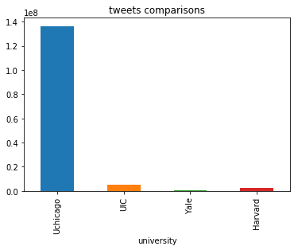

```python
tweeters_user_count.plot(kind='bar',x='university', y='total_statuses_count', legend=None, title="tweets comparisons")
```

### We analysed the tweets of one tweeterer and see that he tweets more about Uchicago than the other universities

## 5) Where are these Twitterers located?

- For UChicago
- For other universities
- Do you see any relationship between university locations and Twitterers’ locations?
- Visualize the relationships

```python
%time teewts_df_uchicago_userloc=tweets_df_uc_clean.filter(col('location').isNotNull()).\
groupBy(['location']).\
agg(count('id').alias('total_count_in_location')).\
orderBy('total_count_in_location',ascending=False).limit(5).toPandas()
teewts_df_uchicago_userloc.head()
```

```
CPU times: user 14.3 ms, sys: 5.34 ms, total: 19.6 ms
Wall time: 10.4 s
```

|  | location | total_count_in_location |
| --- | --- | --- |
| 0 | Chicago, IL | 45179 |
| 1 | Chicago | 13261 |
| 2 | Chicago, Illinois | 8860 |
| 3 | United States | 4187 |
| 4 | Washington, DC | 3575 |

```python
%time teewts_df_uic_userloc=tweets_df_uic_clean.filter(col('location').isNotNull()).\
groupBy(['location']).\
agg(count('id').alias('total_count_in_location')).\
orderBy('total_count_in_location',ascending=False).limit(5).toPandas()
teewts_df_uic_userloc
```

```
CPU times: user 13 ms, sys: 4.63 ms, total: 17.7 ms
Wall time: 8.54 s
```

|  | location | total_count_in_location |
| --- | --- | --- |
| 0 | Chicago, IL | 62916 |
| 1 | Chicago | 18006 |
| 2 | United States | 4132 |
| 3 | Paris, France | 3989 |
| 4 | Illinois, USA | 3706 |

```python
%time teewts_df_h_userloc=tweets_df_harvard_clean.filter(col('location').isNotNull()).\
groupBy(['location']).\
agg(count('id').alias('total_count_in_location')).\
orderBy('total_count_in_location',ascending=False).limit(5).toPandas()
teewts_df_h_userloc
```

```
CPU times: user 14.3 ms, sys: 4.56 ms, total: 18.8 ms
Wall time: 13.4 s
```

|  | location | total_count_in_location |
| --- | --- | --- |
| 0 | United States | 88983 |
| 1 | Boston, MA | 31875 |
| 2 | India | 31602 |
| 3 | USA | 30578 |
| 4 | Cambridge, MA | 27436 |

```python
%time teewts_df_yale_userloc=tweets_df_yale_clean.filter(col('location').isNotNull()).\
groupBy(['location']).\
agg(count('id').alias('total_count_in_location')).\
orderBy('total_count_in_location',ascending=False).limit(5).toPandas()
teewts_df_yale_userloc
```

```
CPU times: user 10.7 ms, sys: 6.25 ms, total: 17 ms
Wall time: 8.8 s
```

|  | location | total_count_in_location |
| --- | --- | --- |
| 0 | United States | 19787 |
| 1 | USA | 7017 |
| 2 | New Haven, CT | 5802 |
| 3 | California, USA | 5385 |
| 4 | Texas, USA | 4705 |

```
CPU times: user 50.1 ms, sys: 1.98 ms, total: 52.1 ms
Wall time: 49.9 ms
```

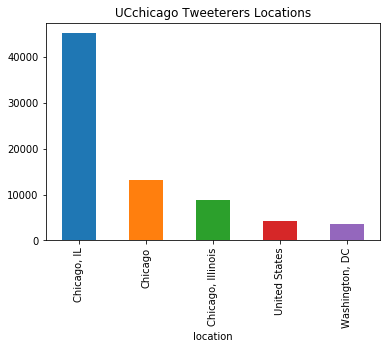

```python
%time my_plot =teewts_df_uchicago_userloc.plot(kind='bar',x='location', y='total_count_in_location', legend=None, title="UCchicago Tweeterers Locations")
#my_plot.set_xlabel("Gender")
#my_plot.set_ylabel("mean_user_friend")
```

## What distinguishes University of Chicago Twitterers vs Twitterers who tweet about other universities

- Visualize the trends

```python
df = {'university': ['uchicago','UIC','yale','harvard'], 'mean_tweeter_user_count': [tweets_df_uc_clean.agg(round(mean('followers_count'))).toPandas().iloc[0].values[0],
                                                                                     tweets_df_uic_clean.agg(round(mean('followers_count'))).toPandas().iloc[0].values[0],
                                                                                    tweets_df_yale_clean.agg(round(mean('followers_count'))).toPandas().iloc[0].values[0],
                                                                                    tweets_df_harvard_clean.agg(round(mean('followers_count'))).toPandas().iloc[0].values[0]]}
mean_tweeters_user_count =pd.DataFrame(data=df)
mean_tweeters_user_count
```

|  | university | mean_tweeter_user_count |
| --- | --- | --- |
| 0 | uchicago | 6450.0 |
| 1 | UIC | 4321.0 |
| 2 | yale | 9235.0 |
| 3 | harvard | 7456.0 |

```
CPU times: user 55 ms, sys: 4.1 ms, total: 59.1 ms
Wall time: 55.8 ms
```

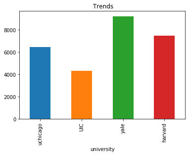

```python
%time my_plot = mean_tweeters_user_count.plot(kind='bar',x='university', y='mean_tweeter_user_count', legend=None, title=" Trends")
```

```python
d2 = { 'university': ['uchicago','UIC','yale', 'harvard'], 'mean_statuses_count' : [tweets_df_uc_clean.agg(round(mean('statuses_count'))).toPandas().iloc[0].values[0],
                                                                                    tweets_df_uic_clean.agg(round(mean('statuses_count'))).toPandas().iloc[0].values[0],
                                                                                    tweets_df_yale_clean.agg(round(mean('statuses_count'))).toPandas().iloc[0].values[0],
                                                                                    tweets_df_harvard_clean.agg(round(mean('statuses_count'))).toPandas().iloc[0].values[0]]}

tweeters_statuses_count =pd.DataFrame(data=d2)
tweeters_statuses_count
```

|  | university | mean_statuses_count |
| --- | --- | --- |
| 0 | uchicago | 26642.0 |
| 1 | UIC | 25996.0 |
| 2 | yale | 51525.0 |
| 3 | harvard | 40495.0 |

```
CPU times: user 52.9 ms, sys: 10.6 ms, total: 63.4 ms
Wall time: 59.2 ms
```

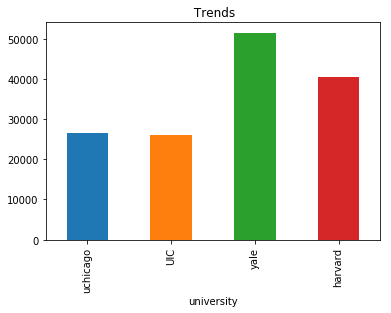

```python
%time my_plot = tweeters_statuses_count.plot(kind='bar',x='university', y='mean_statuses_count', legend=None, title=" Trends")
```

```
CPU times: user 53.5 ms, sys: 2.5 ms, total: 56 ms
Wall time: 52.9 ms
```

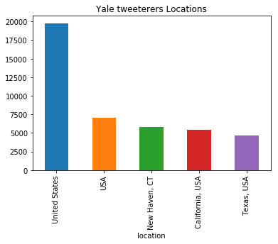

```python
%time my_plot =teewts_df_yale_userloc.plot(kind='bar',x='location', y='total_count_in_location', legend=None, title="Yale tweeterers Locations")
```

```
CPU times: user 51.8 ms, sys: 2.64 ms, total: 54.4 ms
Wall time: 50.6 ms
```

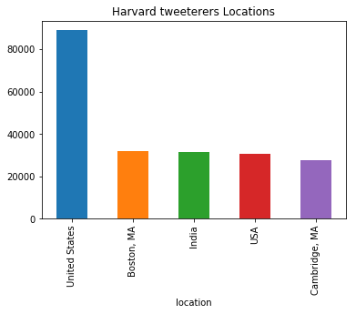

```python
%time my_plot =teewts_df_h_userloc.plot(kind='bar',x='location', y='total_count_in_location', legend=None, title="Harvard tweeterers Locations")
```

## What are the timelines of these tweets? Do you see significant peaks and valleys?

- Do you see data collection gaps?

```python
tweets_df_uc_clean.printSchema()
```

```
root
 |-- created_at: string (nullable = true)
 |-- id: long (nullable = true)
 |-- text: string (nullable = true)
 |-- location: string (nullable = true)
 |-- followers_count: integer (nullable = true)
 |-- name: string (nullable = true)
 |-- statuses_count: integer (nullable = true)
 |-- listed_count: integer (nullable = true)
```

```python
tweets_df_uc_clean.head(5)
```

```
[Row(created_at='Thu Jun 22 23:28:13 +0000 2017', id=719274394816610304, text='Non-UChicago people ignore this tweet...\nTHE IOP ISNT WORTH IT WITHOUT STEVE EDWARDS\nLONG LIVE WBEZ CHICAGO https://t.co/t5EGQGXcW0', location=None, followers_count=420, name='Mikala Paula', statuses_count=5739, listed_…
 Row(created_at='Thu Jun 22 23:36:01 +0000 2017', id=815616970938863616, text='RT @HdxAcademy: We congratulate @UChicago &amp; Pres R. Zimmer on their top rating in our Guide to Colleges: Top 150 Universities:… ', location='United States', followers_count=33, name='Elizabeth Marquardt', statuses_cou…
 Row(created_at='Thu Jun 22 23:42:33 +0000 2017', id=869569854138798080, text='Great visit from @UChicago students #PaulSereno lab! Exhibits, #histology #anagensis #dinosaurs! FUN w/… https://t.co/byatkv4uth', location='Bozeman, MT', followers_count=293, name='MuseumoftheRockies', statuses_count=120…
 Row(created_at='Thu Jun 22 23:43:41 +0000 2017', id=186637685, text="#thursdaythought: “Shadowing attorneys this week, I felt connected to the Center's clients and their stories.”-Emma Gardner @UChicago intern", location='Los Angeles', followers_count=454, name='Harriett Buhai Cntr', statuses_count…
 Row(created_at='Thu Jun 22 23:48:16 +0000 2017', id=3162434887, text='RT @MORPaleo: Great visit from @UChicago students #PaulSereno lab! Exhibits, #histology #anagensis #dinosaurs! FUN w/… ', location='ブルースター首都ユニオン', followers_count=875, name='らえらぷす/ジュラルC', statuses_count=107954, listed_count=77)]
```

```python
df_agg3=tweets_df_uc_clean.select(substring(tweets_df_uc_clean['created_at'], -4, 4).alias('year'),substring(tweets_df_uc_clean['created_at'], 5, 3).alias('month'))
```

```python
df_agg3.limit(5)
```

| year | month |
| --- | --- |
| 2017 | Jun |
| 2017 | Jun |
| 2017 | Jun |
| 2017 | Jun |
| 2017 | Jun |

```python
#df_agg3=  df_agg3.groupBy('year').count()
```

```python
df_time=df_agg3.groupBy('year','month').count().orderBy(["year","month"],ascending=[0,0])
```

```python
df_time.show(3)
```

```
+----+-----+-----+
|year|month|count|
+----+-----+-----+
|2021|  Mar| 4529|
|2021|  Jan| 6874|
|2021|  Feb| 6023|
+----+-----+-----+
only showing top 3 rows
```

```python
df_time =df_time.toPandas()
```

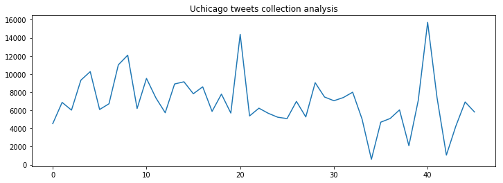

```python
df_time.plot(y="count", figsize=(12,4),legend=None, title="Uchicago tweets collection analysis")
```

```python
df_agg4=df_agg3.groupBy('year').count()
```

```python
df_agg4=df_agg4.orderBy('year', ascending= False).toPandas()
```

[output not shown]

```python
df_year=df_agg3.groupBy('year').count().orderBy(["year"],ascending=[0])
```

```python
df_year=df_year.toPandas()
```

```
CPU times: user 111 ms, sys: 28.7 ms, total: 140 ms
Wall time: 136 ms
```

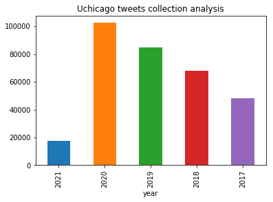

```python
%time my_plot =df_year.plot(kind='bar',x='year', y='count', legend=None, title="Uchicago tweets collection analysis")
```